# PRACTICA4: Trabajar con tablas o marcos de datos con R

Última actualización:

18 de mayo de 2026

# Preparación

En esta práctica trabajaremos en el entorno de R, con los paquetes siguientes: dplyr, kableExtra y jsonlite. Para descargar algunos datos de ejemplo, usaremos los programas datasets y dataformat (O’Leary et al. 2024), que pueden descargarse en este enlace.

# Objetivos

- Conocer el uso de datasets y dataformat.
- Ver algún ejemplo de archivo en formato JSON.
- Manipular marcos de datos sin usar hojas de cálculo.

# Datos

Supón que tenemos interés en descargar un genoma de referencia de cualquier especie del género Trypanosoma, así como su anotación funcional, en formato GFF3. Veamos primero de qué opciones disponemos:

```bash
DATA=/mnt/c/Documents/Bioinformatica/data/Practica4
mkdir -p "$DATA"

if [ ! -e "$DATA/trypanosoma_annotated.txt" ]; then
   datasets summary genome taxon Trypanosoma --annotated --as-json-lines | \
   dataformat tsv genome --fields \
      accession,organism-name,assminfo-release-date,assminfo-level,assmstats-atgc-count,annotinfo-featcount-gene-total,assminfo-type,assminfo-status > "$DATA/trypanosoma_annotated.txt"
fi
```

[output not shown]

La línea larga que sigue a –fields especifica qué información sobre los genomas queremos ver en la tabla. Para saber qué campos se pueden seleccionar, puedes ejecutar la orden dataformat tsv genome –help. Veamos esa tabla en el informe HTML en un formato adecuado.

```r
library('kableExtra')
DATA_R <- "~/Bioinformatica/data/Practica4"

genomas <- read.table(file.path(DATA_R, 'trypanosoma_annotated.txt'),
                      header = TRUE, sep = '\t')
kable(genomas) %>% kable_styling()
```

| Assembly.Accession | Organism.Name | Assembly.Release.Date | Assembly.Level | Assembly.Stats.ATGC.Count | Annotation.Count.Gene.Total | Assembly.Type | Assembly.Status |
| --- | --- | --- | --- | --- | --- | --- | --- |
| GCF_000002445.2 | Trypanosoma brucei brucei TREU927 | 2005-12-14 | Chromosome | 27984184 | 10221 | haploid | current |
| GCA_000002445.1 | Trypanosoma brucei brucei TREU927 | 2005-12-14 | Chromosome | 27984184 | 10234 | haploid | current |
| GCA_003543875.1 | Trypanosoma brucei equiperdum | 2018-09-11 | Chromosome | 26988976 | 10293 | haploid | current |
| GCF_000210295.1 | Trypanosoma brucei gambiense DAL972 | 2009-10-14 | Chromosome | 22110721 | 9930 | haploid | current |
| GCA_000210295.1 | Trypanosoma brucei gambiense DAL972 | 2009-10-14 | Chromosome | 22110721 | 9961 | haploid | current |
| GCA_000227395.2 | Trypanosoma congolense IL3000 | 2011-08-12 | Scaffold | 18802389 | 6348 | haploid | current |
| GCF_003719485.1 | Trypanosoma conorhini | 2018-11-08 | Scaffold | 21137671 | 10321 | haploid | current |
| GCA_003719485.1 | Trypanosoma conorhini | 2018-11-08 | Scaffold | 21137671 | 10321 | haploid | current |
| GCF_000209065.1 | Trypanosoma cruzi | 2005-08-02 | Scaffold | 89612356 | 25210 | unresolved-diploid | current |
| GCA_000188675.2 | Trypanosoma cruzi | 2012-10-02 | Contig | 38589511 | 10876 | haploid | current |
| GCA_000209065.1 | Trypanosoma cruzi | 2005-08-02 | Scaffold | 89612356 | 25210 | unresolved-diploid | current |
| GCA_003177095.1 | Trypanosoma cruzi | 2018-05-30 | Contig | 87058484 | 29302 | unresolved-diploid | current |
| GCA_003177105.1 | Trypanosoma cruzi | 2018-05-30 | Contig | 53271887 | 19115 | haploid | current |
| GCA_003719155.1 | Trypanosoma cruzi | 2018-11-05 | Scaffold | 20565523 | 34344 | diploid | current |
| GCA_003719455.1 | Trypanosoma cruzi | 2018-11-08 | Scaffold | 23852162 | 13503 | haploid | current |
| GCA_013358655.1 | Trypanosoma cruzi | 2020-06-18 | Scaffold | 40788336 | 14352 | haploid | current |
| GCA_015033625.1 | Trypanosoma cruzi | 2020-11-03 | Chromosome | 45527284 | 18708 | haploid | current |
| GCA_015033655.1 | Trypanosoma cruzi | 2020-11-03 | Chromosome | 47195002 | 17651 | haploid | current |
| GCA_002219105.2 | Trypanosoma cruzi cruzi | 2017-09-15 | Contig | 50928259 | 22870 | haploid | current |
| GCA_000496795.1 | Trypanosoma cruzi Dm28c | 2013-11-13 | Contig | 27304309 | 11398 | haploid | current |
| GCA_000300495.1 | Trypanosoma cruzi marinkellei | 2012-10-01 | Contig | 34226154 | 10127 | haploid | current |
| GCF_001457755.1 | Trypanosoma equiperdum | 2016-12-15 | Scaffold | 26113307 | 9129 | haploid | current |
| GCA_001457755.2 | Trypanosoma equiperdum | 2016-12-15 | Scaffold | 26113307 | 9135 | haploid | current |
| GCF_000691245.1 | Trypanosoma grayi | 2014-05-15 | Scaffold | 20791447 | 10676 | haploid | current |
| GCA_000691245.1 | Trypanosoma grayi | 2014-05-15 | Scaffold | 20791447 | 10676 | haploid | current |
| GCF_022059095.1 | Trypanosoma melophagium | 2022-02-08 | Contig | 23303718 | 9756 | haploid | current |
| GCA_022059095.1 | Trypanosoma melophagium | 2022-02-08 | Contig | 23303718 | 9768 | haploid | current |
| GCF_003719475.1 | Trypanosoma rangeli | 2018-11-08 | Scaffold | 20977846 | 10589 | haploid | current |
| GCA_003719475.1 | Trypanosoma rangeli | 2018-11-08 | Scaffold | 20977846 | 10589 | haploid | current |
| GCA_000492115.1 | Trypanosoma rangeli SC58 | 2013-10-30 | Contig | 15111138 | 7475 | haploid | current |
| GCF_002087225.1 | Trypanosoma theileri | 2017-04-12 | Scaffold | 25688935 | 11312 | haploid | current |
| GCA_002087225.1 | Trypanosoma theileri | 2017-04-12 | Scaffold | 25688935 | 11312 | haploid | current |
| GCA_021307395.1 | Trypanosoma vivax | 2021-12-28 | Contig | 67823889 | 17806 | haploid | current |
| GCA_019425475.1 | Trypanosoma vivax | 2021-07-30 | Contig | 23865041 | 10424 | haploid | current |
| GCA_000227375.1 | Trypanosoma vivax Y486 | 2011-08-11 | Contig | 24779298 | 4122 | haploid | current |

**Nota**

#Desafio ¿Qué diferencia hay entre las líneas 7 y 8 de la tabla anterior?

Busca una función de R que te permita identificar las líneas repetidas en un marco de datos.

La función de R diseñada específicamente para esto es duplicated(). Devuelve un vector lógico indicando qué filas son copias exactas de filas anteriores.

```r
genomas[duplicated(genomas), ]
```

```
[1] Assembly.Accession          Organism.Name
[3] Assembly.Release.Date       Assembly.Level
[5] Assembly.Stats.ATGC.Count   Annotation.Count.Gene.Total
[7] Assembly.Type               Assembly.Status
<0 rows> (o 0- extensión row.names)
```

#Ordenar una tabla

La función order() produce los índices ordenados de los elementos de un vector. Consulta su ayuda y experimenta con ella. Vamos a usar esta función para ordenar las filas del marco de datos genomas por fecha, que es la tercera columna, llamada Assembly.Release.Date.

```r
# Observa que asignamos el resultado del ordenamiento al mismo objeto que
# estamos ordenando, para guardar el resultado sin tener que generar otro objeto.
genomas <- genomas[order(genomas$Assembly.Release.Date), ]
kable(genomas) %>% kable_styling()
```

|  | Assembly.Accession | Organism.Name | Assembly.Release.Date | Assembly.Level | Assembly.Stats.ATGC.Count | Annotation.Count.Gene.Total | Assembly.Type | Assembly.Status |
| --- | --- | --- | --- | --- | --- | --- | --- | --- |
| 9 | GCF_000209065.1 | Trypanosoma cruzi | 2005-08-02 | Scaffold | 89612356 | 25210 | unresolved-diploid | current |
| 11 | GCA_000209065.1 | Trypanosoma cruzi | 2005-08-02 | Scaffold | 89612356 | 25210 | unresolved-diploid | current |
| 1 | GCF_000002445.2 | Trypanosoma brucei brucei TREU927 | 2005-12-14 | Chromosome | 27984184 | 10221 | haploid | current |
| 2 | GCA_000002445.1 | Trypanosoma brucei brucei TREU927 | 2005-12-14 | Chromosome | 27984184 | 10234 | haploid | current |
| 4 | GCF_000210295.1 | Trypanosoma brucei gambiense DAL972 | 2009-10-14 | Chromosome | 22110721 | 9930 | haploid | current |
| 5 | GCA_000210295.1 | Trypanosoma brucei gambiense DAL972 | 2009-10-14 | Chromosome | 22110721 | 9961 | haploid | current |
| 35 | GCA_000227375.1 | Trypanosoma vivax Y486 | 2011-08-11 | Contig | 24779298 | 4122 | haploid | current |
| 6 | GCA_000227395.2 | Trypanosoma congolense IL3000 | 2011-08-12 | Scaffold | 18802389 | 6348 | haploid | current |
| 21 | GCA_000300495.1 | Trypanosoma cruzi marinkellei | 2012-10-01 | Contig | 34226154 | 10127 | haploid | current |
| 10 | GCA_000188675.2 | Trypanosoma cruzi | 2012-10-02 | Contig | 38589511 | 10876 | haploid | current |
| 30 | GCA_000492115.1 | Trypanosoma rangeli SC58 | 2013-10-30 | Contig | 15111138 | 7475 | haploid | current |
| 20 | GCA_000496795.1 | Trypanosoma cruzi Dm28c | 2013-11-13 | Contig | 27304309 | 11398 | haploid | current |
| 24 | GCF_000691245.1 | Trypanosoma grayi | 2014-05-15 | Scaffold | 20791447 | 10676 | haploid | current |
| 25 | GCA_000691245.1 | Trypanosoma grayi | 2014-05-15 | Scaffold | 20791447 | 10676 | haploid | current |
| 22 | GCF_001457755.1 | Trypanosoma equiperdum | 2016-12-15 | Scaffold | 26113307 | 9129 | haploid | current |
| 23 | GCA_001457755.2 | Trypanosoma equiperdum | 2016-12-15 | Scaffold | 26113307 | 9135 | haploid | current |
| 31 | GCF_002087225.1 | Trypanosoma theileri | 2017-04-12 | Scaffold | 25688935 | 11312 | haploid | current |
| 32 | GCA_002087225.1 | Trypanosoma theileri | 2017-04-12 | Scaffold | 25688935 | 11312 | haploid | current |
| 19 | GCA_002219105.2 | Trypanosoma cruzi cruzi | 2017-09-15 | Contig | 50928259 | 22870 | haploid | current |
| 12 | GCA_003177095.1 | Trypanosoma cruzi | 2018-05-30 | Contig | 87058484 | 29302 | unresolved-diploid | current |
| 13 | GCA_003177105.1 | Trypanosoma cruzi | 2018-05-30 | Contig | 53271887 | 19115 | haploid | current |
| 3 | GCA_003543875.1 | Trypanosoma brucei equiperdum | 2018-09-11 | Chromosome | 26988976 | 10293 | haploid | current |
| 14 | GCA_003719155.1 | Trypanosoma cruzi | 2018-11-05 | Scaffold | 20565523 | 34344 | diploid | current |
| 7 | GCF_003719485.1 | Trypanosoma conorhini | 2018-11-08 | Scaffold | 21137671 | 10321 | haploid | current |
| 8 | GCA_003719485.1 | Trypanosoma conorhini | 2018-11-08 | Scaffold | 21137671 | 10321 | haploid | current |
| 15 | GCA_003719455.1 | Trypanosoma cruzi | 2018-11-08 | Scaffold | 23852162 | 13503 | haploid | current |
| 28 | GCF_003719475.1 | Trypanosoma rangeli | 2018-11-08 | Scaffold | 20977846 | 10589 | haploid | current |
| 29 | GCA_003719475.1 | Trypanosoma rangeli | 2018-11-08 | Scaffold | 20977846 | 10589 | haploid | current |
| 16 | GCA_013358655.1 | Trypanosoma cruzi | 2020-06-18 | Scaffold | 40788336 | 14352 | haploid | current |
| 17 | GCA_015033625.1 | Trypanosoma cruzi | 2020-11-03 | Chromosome | 45527284 | 18708 | haploid | current |
| 18 | GCA_015033655.1 | Trypanosoma cruzi | 2020-11-03 | Chromosome | 47195002 | 17651 | haploid | current |
| 34 | GCA_019425475.1 | Trypanosoma vivax | 2021-07-30 | Contig | 23865041 | 10424 | haploid | current |
| 33 | GCA_021307395.1 | Trypanosoma vivax | 2021-12-28 | Contig | 67823889 | 17806 | haploid | current |
| 26 | GCF_022059095.1 | Trypanosoma melophagium | 2022-02-08 | Contig | 23303718 | 9756 | haploid | current |
| 27 | GCA_022059095.1 | Trypanosoma melophagium | 2022-02-08 | Contig | 23303718 | 9768 | haploid | current |

Casualmente, la fecha estaba en formato “%Y-%m-%d”, en el que el orden alfabético coincide con el orden temporal. Al crear genomas, read.table() había interpretado la tercera columna como texto. Para que las fechas sean entendidas como tales, podemos usar la función as.Date():

```r
genomas$Assembly.Release.Date <- as.Date(genomas$Assembly.Release.Date,
                                         '%Y-%m-%d')
```

Una vez convertida en “fecha”, la columna “Assembly.Release.Date” puede usarse correctamente, por ejemplo, como eje de abscisas en una gráfica:

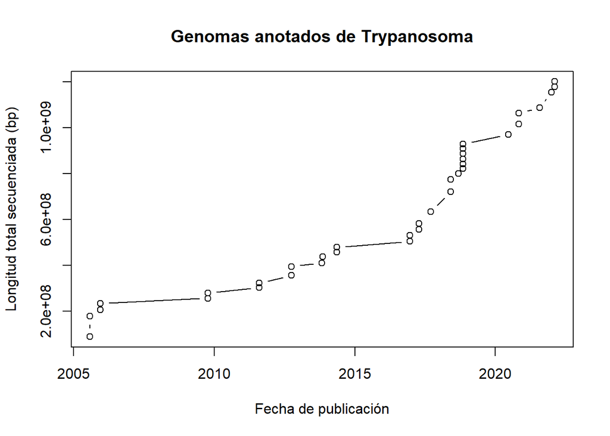

```r
# Aquí usamos "cumsum()" para obtener la suma acumulada del número de bases
# secuenciadas.
plot(x = genomas$Assembly.Release.Date,
     y = cumsum(genomas$Assembly.Stats.ATGC.Count),
     type = 'b',
     xlab = 'Fecha de publicación',
     ylab = 'Longitud total secuenciada (bp)',
     main = 'Genomas anotados de Trypanosoma')
```

#Archivos JSON y GFF Habiendo visto las opciones, decidimos descargar el genoma y la anotación funcional de una de ellas, por ejemplo GCA_022059095.1.

```bash
DATA=/mnt/c/Documents/Bioinformatica/data/Practica4
mkdir -p "$DATA"
cd "$DATA" # Entramos en la carpeta para que el ZIP se descargue y descomprima allí

if [ ! -e ncbi_dataset/data/GCA_022059095.1/genomic.gff ]; then
   if [ ! -e ncbi_dataset.zip ]; then
      datasets download genome accession GCA_022059095.1 --include genome,gff3
   fi
   # Añadimos -o para sobrescribir sin preguntar en caso de existir parcialmente
   unzip -o ncbi_dataset.zip
fi
```

[output not shown]

[output cut: 147 more lines]

```
Downloading: ncbi_dataset.zip    7.96MB done
Validating package files [=======================>------------------------]  50% 3/6
Downloading: ncbi_dataset.zip    7.96MB done
Validating package files [=======================>------------------------]  50% 3/6
Downloading: ncbi_dataset.zip    7.96MB done
Validating package files [=======================>------------------------]  50% 3/6
Downloading: ncbi_dataset.zip    7.96MB valid data package
Validating package files [================================================] 100% 6/6
Archive:  ncbi_dataset.zip
  inflating: README.md
  inflating: ncbi_dataset/data/assembly_data_report.jsonl
  inflating: ncbi_dataset/data/GCA_022059095.1/GCA_022059095.1_T.mel.1_genomic.fna
  inflating: ncbi_dataset/data/GCA_022059095.1/genomic.gff
  inflating: ncbi_dataset/data/dataset_catalog.json
  inflating: md5sum.txt
```

En la carpeta ncbi_dataset/data encontrarás un archivo en formato JSON con información sobre los datos descargados, y un archivo en formato “jsonlines”. El formato “jsonlines” es una versión de JSON en la que cada registro ocupa una sola línea. Esto dificulta la visualización, pero agiliza el análisis de los datos en la línea de órdenes. Para ver mejor el contenido del archivo con la extensión jsonl, podríamos utilizar el programa jq, o bien utilizar la función prettify() del paquete jsonlite de R:

```r
library('jsonlite')
DATA_R <- "~/Bioinformatica/data/Practica4"
prettify(readLines(file.path(DATA_R, 'ncbi_dataset/data/assembly_data_report.jsonl')))
```

```
{
    "assemblyInfo": {
        "assemblyLevel": "Contig",
        "assemblyName": "T.mel.1",
        "assemblyType": "haploid",
        "submitter": "University of Edinburgh",
        "refseqCategory": "reference genome",
        "bioprojectLineage": [
            {
                "bioprojects": [
                    {
                        "accession": "PRJNA786535",
                        "title": "Trypanosoma melophagium isolate:St. Kilda Genome sequencing and assembly"
                    }
                ]
            }
        ],
        "sequencingTech": "Oxford Nanopore MinION; DNBseq",
        "blastUrl": "https://blast.ncbi.nlm.nih.gov/Blast.cgi?PAGE_TYPE=BlastSearch&PROG_DEF=blastn&BLAST_SPEC=GDH_GCA_022059095.1",
        "biosample": {
            "accession": "SAMN23701209",
            "lastUpdated": "2021-12-29T05:45:01.878",
            "publicationDate": "2021-12-29T00:00:00.000",
            "submissionDate": "2021-12-06T10:53:03.556",
            "sampleIds": [
                {
                    "label": "Sample name",
                    "value": "T. melophagium"
                },
                {
                    "db": "SRA",
                    "value": "SRS11278131"
                }
            ],
            "description": {
                "title": "MIGS Eukaryotic sample from Trypanosoma melophagium",
                "organism": {
                    "taxId": 715481,
                    "organismName": "Trypanosoma melophagium"
                },
```

[output cut: 117 more lines]

```
        "wgsContigsUrl": "https://www.ncbi.nlm.nih.gov/Traces/wgs/JAJSEB01"
    },
    "currentAccession": "GCA_022059095.1",
    "accession": "GCA_022059095.1",
    "pairedAccession": "GCF_022059095.1",
    "sourceDatabase": "SOURCE_DATABASE_GENBANK",
    "organism": {
        "taxId": 715481,
        "organismName": "Trypanosoma melophagium",
        "infraspecificNames": {
            "ecotype": "St. Kilda",
            "isolate": "St. Kilda"
        }
    }
}
```

Volviendo a lo que nos interesa, vamos a cargar en un marco de datos de una sesión de R la anotación funcional del genoma escogido. Aunque existen funciones específicas para leer archivos GFF, usaremos la función básica read.table(), con alguna precaución.

```r
DATA_R <- "~/Bioinformatica/data/Practica4"
# Como no tiene cabecera, le damos los nombres de las columnas:
gff <- read.table(file.path(DATA_R, 'ncbi_dataset/data/GCA_022059095.1/genomic.gff'),
                  sep = '\t',
                  col.names = c('seqid', 'source', 'type', 'start', 'end',
                                'score', 'strand', 'phase', 'attributes'),
                  quote = '')
```

Al leer el archivo GFF con read.table(), debemos especificar que el separador de columnas es el tabulador y que no hay texto entrecomillado en el archivo. Esto último se consigue con la opción quote = ’’, y sirve para evitar que todo lo que se encuentre entre dos apóstrofes (’) se considere parte de un mismo campo de información, aunque sean cientos de líneas.

Para comprobar que el archivo ha sido leído completo y sin errores, conviene revisar las dimensiones del marco de datos (dim(gff)) o incluso visualizar el principio (head(gff)) y el final (tail(gff)) del objeto, que es demasiado grande para mostrarlo en pantalla completo.

#Seleccionar filas y columnas En el objeto gff hay 5 valores diferentes de la variable type: “CDS”, “exon”, “gene”, “mRNA” y “region”. Puedes comprobarlo con unique(gff$type), o con table(gff$type). Podemos separar la tabla en cinco marcos de datos, que correspondan a esos cinco tipos de anotación funcional.

```r
# Usamos un vector booleano como índice de las filas.
# En las tablas nuevas, no necesitamos la tercera columna
# y la eliminamos con el "-3".
gene   <- gff[gff$type == 'gene',   -3]
mrna   <- gff[gff$type == 'mRNA',   -3]
exon   <- gff[gff$type == 'exon',   -3]
cds    <- gff[gff$type == 'CDS',    -3]
region <- gff[gff$type == 'region', -3]
# Alinear las órdenes nos ayuda a detectar posibles errores
```

**Nota**

Desafío Identifica en cada uno de estos marcos de datos qué columnas son invariables. Es decir, las columnas que tienen el mismo valor en todas las líneas. Y elimina esas columnas.

**Nota**

Solución al Desafío Una columna es invariable si al mirar sus valores únicos, solo hay 1. Por ejemplo, en los archivos GFF es muy habitual que el score o el source sean siempre iguales (como el valor .). Podemos eliminar automáticamente de gene aquellas columnas que tienen un solo valor único:

```r
# Se seleccionan solo aquellas columnas que tengan más de 1 valor único
gene <- gene[, sapply(gene, function(x) length(unique(x)) > 1)]
head(gene, 2)
```

```
              seqid start  end strand
2 JAJSEB010000004.1   246  935      -
8 JAJSEB010000004.1  2204 2776      +
                                                                                            attributes
2 ID=gene-LSM04_009031;Name=LSM04_009031;gbkey=Gene;gene_biotype=protein_coding;locus_tag=LSM04_009031
8 ID=gene-LSM04_007573;Name=LSM04_007573;gbkey=Gene;gene_biotype=protein_coding;locus_tag=LSM04_007573
```

Agrupar, operar y resumir Habiendo separado los diferentes tipos de anotaciones, ahora resulta fácil obtener estadísticas de cada uno. Podemos querer una tabla que nos diga para cada tipo de anotación, cuántos elementos de ese tipo hay en el genoma, qué longitud media tienen y qué desviación estándar. Hay diferentes maneras de conseguirlo. La más rudimentaria implicaría obtener cada estadística individualmente y después juntarlas en una nueva tabla. Por ejemplo, para regiones codificantes (“CDS”):

```r
cds$longitud <- cds$end - cds$start + 1
resumen <- data.frame(
   tipo       = 'CDS',
   número     = nrow(cds),
   long.Media = mean(cds$longitud),
   long.SD    = sd(cds$longitud)
)
```

**Nota**

Desafío ¿Sabrías completar el marco de datos resumen con los datos de los otros cuatro tipos de anotación funcional?

**Nota**

Solución al Desafío Para completarlo, primero debemos calcular la columna $longitud en los demás dataframes y, a continuación, quitar la coma sobrante y concatenar las variables en vectores:

```r
gene$longitud   <- gene$end - gene$start + 1
mrna$longitud   <- mrna$end - mrna$start + 1
exon$longitud   <- exon$end - exon$start + 1
region$longitud <- region$end - region$start + 1

resumen_completo <- data.frame(
   tipo       = c('CDS', 'gene', 'mRNA', 'exon', 'region'),
   número     = c(nrow(cds), nrow(gene), nrow(mrna), nrow(exon), nrow(region)),
   long.Media = c(mean(cds$longitud), mean(gene$longitud), mean(mrna$longitud), mean(exon$longitud), mean(region$longitud)),
   long.SD    = c(sd(cds$longitud), sd(gene$longitud), sd(mrna$longitud), sd(exon$longitud), sd(region$longitud))
)
kable(resumen_completo) %>% kable_styling(full_width = FALSE)
```

| tipo | número | long.Media | long.SD |
| --- | --- | --- | --- |
| CDS | 11304 | 1358.661 | 1377.899 |
| gene | 9768 | 1553.822 | 1466.322 |
| mRNA | 10057 | 1549.331 | 1466.240 |
| exon | 11304 | 1358.661 | 1377.899 |
| region | 64 | 364120.594 | 314801.149 |

Este tipo de operación es bastante habitual, y se puede hacer sin necesidad de crear marcos de datos parciales. La función split() divide las líneas de un marco de datos en tantos marcos de datos como valores diferentes (niveles) haya en el factor que usemos para definir los grupos. El resultado es un solo objeto: una lista de marcos de datos:

```r
# Esto es una lista de marcos de datos:
porTipo <- split(gff, gff$type)
# Estas funciones nos permiten inspeccionar algunas características
# del nuevo objeto:
class(porTipo)
```

```
[1] "list"
```

```r
length(porTipo)
```

```
[1] 5
```

```r
names(porTipo)
```

```
[1] "CDS"    "exon"   "gene"   "mRNA"   "region"
```

```r
sapply(porTipo, class)
```

```
         CDS         exon         gene         mRNA       region
"data.frame" "data.frame" "data.frame" "data.frame" "data.frame"
```

```r
sapply(porTipo, nrow)
```

```
   CDS   exon   gene   mRNA region
 11304  11304   9768  10057     64
```

La función sapply(), toma al menos dos argumentos: una lista (o vector) y una función. Devuelve un vector (si es posible) con los resultados de aplicar la función a cada elemento de la lista. Con esto, el resumen que queríamos se puede obtener así:

```r
# Primero calculamos las longitudes de todas las anotaciones en gff:
gff$longitud <- gff$end - gff$start + 1
# Volvemos a separar las filas por tipo, ahora que tenemos las longitudes:
porTipo <- split(gff, gff$type)
resumen <- data.frame(
   tipo = names(porTipo),
   número = sapply(porTipo, nrow),
   long.Media = sapply(porTipo, function(x) mean(x$longitud)),
   long.SD    = sapply(porTipo, function(x) sd(x$longitud))
)

# Aprovechamos para mostrar nombres de columnas más legibles:
kable(resumen,
      col.names = c('Tipo', 'Número', 'Longitud Media',
                    'Desviación estándar'),
      row.names = FALSE) %>%
    kable_styling(full_width = FALSE)
```

| Tipo | Número | Longitud Media | Desviación estándar |
| --- | --- | --- | --- |
| CDS | 11304 | 1358.661 | 1377.899 |
| exon | 11304 | 1358.661 | 1377.899 |
| gene | 9768 | 1553.822 | 1466.322 |
| mRNA | 10057 | 1549.331 | 1466.240 |
| region | 64 | 364120.594 | 314801.149 |

Las operaciones de agrupar y resumir se pueden hacer también con funciones del paquete dplyr, que forma parte de un conjunto de paquetes diseñados para funcionar armoniosamente entre ellos. Son los paquetes del tidyverse, muy populares en ciencia de datos. Casi se pueden considerar un dialecto de R. Las funciones (o verbos) más interesantes de dplyr son group_by() y summarise().

```r
library('dplyr')
# Observa el uso de "tuberías" ("%>%"):
resumen <- gff %>% group_by(type) %>% summarise(
   número     = n(),
   Long.Media = mean(longitud),
   Long.SD    = sd(longitud)
)
kable(resumen,
      col.names = c('Tipo', 'Número', 'Longitud Media',
                    'Desviación estándar'),
      row.names = FALSE) %>%
   kable_styling(full_width = FALSE)
```

| Tipo | Número | Longitud Media | Desviación estándar |
| --- | --- | --- | --- |
| CDS | 11304 | 1358.661 | 1377.899 |
| exon | 11304 | 1358.661 | 1377.899 |
| gene | 9768 | 1553.822 | 1466.322 |
| mRNA | 10057 | 1549.331 | 1466.240 |
| region | 64 | 364120.594 | 314801.149 |

**Nota**

Desafío Crea una tabla con el número total de genes en cada cromosoma. ¿Puedes contar cuántos hay codificados en cada sentido (“strand”) y en cada cromosoma?

**Nota**

Solución al Desafío Aprovechando dplyr, esto se resuelve agrupando primero por el ID del cromosoma (seqid) y el sentido (strand), y luego contando las filas:

```r
tabla_cromosomas <- gff %>%
  filter(type == "gene") %>%
  group_by(seqid, strand) %>%
  summarise(Total_Genes = n(), .groups = 'drop')

head(tabla_cromosomas)
```

```
# A tibble: 6 × 3
  seqid             strand Total_Genes
  <chr>             <chr>        <int>
1 JAJSEB010000001.1 +              376
2 JAJSEB010000001.1 -              201
3 JAJSEB010000002.1 -                3
4 JAJSEB010000003.1 -               39
5 JAJSEB010000004.1 +               34
6 JAJSEB010000004.1 -               14
```

Comparar o cruzar datos Imagina que un estudio señala los cromosomas siguientes como posiblemente asociados a la resistencia a un fármaco. Quieres saber qué genes hay en estos cinco cromosomas:

JAJSEB010000048.1

JAJSEB010000012.1

JAJSEB010000020.1

JAJSEB010000016.1

JAJSEB010000033.1

Antes hemos usado el operador lógico == para crear un vector booleano con el que seleccionar algunas líneas. En este caso usaremos el operador %in%, que compara conjuntos o vectores de caracteres:

```r
candidatos <- c("JAJSEB010000048.1",
                "JAJSEB010000012.1",
                "JAJSEB010000020.1",
                "JAJSEB010000016.1",
                "JAJSEB010000033.1")
interesantes <- gff[gff$seqid %in% candidatos, ]
dim(interesantes)
```

```
[1] 4792   10
```

**Nota**

Desafío ¿Puedes limitar la selección a anotaciones de tipo “gene”?

**Nota**

Solución al Desafío Añadir la condición adicional utilizando el operador & (AND lógico):

```r
interesantes_genes <- gff[gff$seqid %in% candidatos & gff$type == "gene", ]
dim(interesantes_genes)
```

```
[1] 1097   10
```

El estudio avanza y reduce el tamaño de las regiones candidatas, así que ahora necesitas identificar los genes presentes en exactamente las regiones siguientes:

JAJSEB010000048.1:184638-253478

JAJSEB010000012.1:133444-348860

JAJSEB010000020.1:73393-149614

JAJSEB010000016.1:161247-272009

JAJSEB010000033.1:123135-170687

Aunque existen programas específicos para comparar segmentos cromosómicos (bedtools), continuaremos practicando con marcos de datos de R. Ahora ya no podemos usar %in%, porque de cada cromosoma queremos unos segmentos diferentes. Una estrategia es crear cinco filtros booleanos, y después combinarlos con la operación lógica “o”, es decir |. En cada filtro seleccionaremos las anotaciones que estén completamente contenidas en el intervalo indicado.

```r
f1 <- gff$seqid == 'JAJSEB010000048.1' & gff$start >= 184638 & gff$end <= 253478
f2 <- gff$seqid == 'JAJSEB010000012.1' & gff$start >= 133444 & gff$end <= 348860
f3 <- gff$seqid == 'JAJSEB010000020.1' & gff$start >= 73393  & gff$end <= 149614
f4 <- gff$seqid == 'JAJSEB010000016.1' & gff$start >= 161247 & gff$end <= 272009
f5 <- gff$seqid == 'JAJSEB010000033.1' & gff$start >= 123135 & gff$end <= 170687
f <- f1 | f2 | f3 | f4 | f5
interesantes <- gff[f, ]
```

**Nota**

Desafío ¿Puedes cambiar los filtros para que incluyan también genes parcialmente contenidos en los intervalos indicados?

**Nota**

Solución al Desafío Para que un gen solape o esté parcialmente contenido en un intervalo, su inicio debe ser menor o igual al final del intervalo (para no empezar después) y su final debe ser mayor o igual al inicio del intervalo (para no terminar antes). Modificando el primer filtro como ejemplo:

```r
# Gen partially overlaps completely with interval 184638 to 253478
f1_parcial <- gff$seqid == 'JAJSEB010000048.1' & gff$start <= 253478 & gff$end >= 184638
```

#Las llaves y la función match() En las bases de datos relacionales se llama llave a la columna o al conjunto de columnas cuyos valores identifican unívocamente cada línea de la tabla. En los marcos de datos de R, las líneas pueden tener nombre, el cual puede usarse como llave o índice para seleccionar líneas. Pero el uso del nombre de las líneas no es recomendable. Lo más práctico es que en cualquier tabla haya una columna cuyos valores no puedan repetirse. Esto ayuda a evitar duplicidades, mantener la integridad de la tabla y relacionar unas tablas con otras.

**Nota**

Nota ¿Cuál es la llave en un archivo GFF? Solución: Estrictamente hablando, en un archivo GFF (de 9 columnas) ninguna de las primeras 8 columnas es única de forma aislada. La verdadera llave única se encuentra codificada dentro de la 9ª columna (attributes), concretamente en el campo ID=, que proporciona un identificador unívoco y no repetible para cada elemento biológico anotado.

```r
# Aprenderemos esta sintaxis en el próximo tema:
portal <- 'https://www.ebi.ac.uk/ena/portal/api/search?'
result <- 'result=assembly&'
query  <- 'query=tax_tree(5690)&'
fields <- 'fields=accession%2Cversion%2Cscientific_name%2Cbase_count%2Clast_updated%2Cassembly_level'
URL <- paste0(portal, result, query, fields)
genomas.ena <- read.table(URL, header = TRUE, sep = '\t', quote = '', na.strings = '')
```

Tanto el nuevo marco de datos genomas.ena, como el que habíamos creado antes con datos de NCBI, genomas, tienen una columna de valores únicos: “accession” o “Assembly.Accession”. Para los registros comunes entre las dos tablas, podemos transferir información de una a otra. Por ejemplo, vamos a añadir a la tabla genomas la fecha de última modificación del ensamblaje, que encontramos en genomas.ena. Para asegurarnos de que a cada ensamblaje le asignamos el valor correcto, usaremos la función match().

En genomas, “Assembly.Accession” incluye un sufijo que indica el número de versión del ensamblaje. Este sufijo no está presente en genomas.ena$accession. Para hacer comparables ambas tablas, quitaremos el sufijo de la primera tabla.

```r
# Este es un uso avanzado de `sapply()` y `strsplit()`:
genomas$acc <- sapply(
   strsplit(genomas$Assembly.Accession, '.', fixed = TRUE),
   '[', 1)
genomas$last_updated <- genomas.ena[match(genomas$acc,
                                          genomas.ena$accession),
                                    'last_updated']
```

**Nota**

Desafíos ¿Cómo comprobarías que al eliminar el sufijo de la versión, genomas$acc sigue siendo una llave de la tabla genomas?

Siguiendo el mismo esquema añade a genomas el “base_count” y compáralo con el “Assembly.Stats.ATGC.Count”. Si observas alguna diferencia, intenta explicarla.

Para comprobar que sigue siendo una llave perfecta y única, revisamos si existe algún duplicado en esa nueva columna:

```r
# Si devuelve FALSE, significa que todos los accesos recortados siguen siendo únicos
any(duplicated(genomas$acc))
```

```
[1] FALSE
```

Para añadir el conteo de bases y compararlo:

```r
genomas$base_count <- genomas.ena[match(genomas$acc, genomas.ena$accession), 'base_count']
head(genomas[, c('Assembly.Stats.ATGC.Count', 'base_count')])
```

```
   Assembly.Stats.ATGC.Count base_count
9                   89612356         NA
11                  89612356   89937456
1                   27984184         NA
2                   27984184   26075494
4                   22110721         NA
5                   22110721   22148088
```

#Apéndice En los archivos GFF, la columna attributes es una lista de parejas de valores “clave = valor”, separadas por punto y coma (“;”). Habiendo creado antes un marco de datos para cada tipo de anotación (genes, CDS, etc.), es de suponer que todas las líneas de un marco de datos tendrán el mismo conjunto de parejas “clave = valor”. Aquí se muestra una manera de extraer esta información y convertirla en columnas adicionales de un marco de datos.

Veamos el primer valor de attributes en el marco de datos gene:

```r
gene[1, 'attributes']
```

```
[1] "ID=gene-LSM04_009031;Name=LSM04_009031;gbkey=Gene;gene_biotype=protein_coding;locus_tag=LSM04_009031"
```

La función strsplit() en R divide una cadena de caracteres en partes delimitadas por algún carácter o expresión regular. En este caso, queremos dividir esa cadena por los puntos y coma:

```r
strsplit(gene[1, 'attributes'], ';')
```

```
[[1]]
[1] "ID=gene-LSM04_009031"        "Name=LSM04_009031"
[3] "gbkey=Gene"                  "gene_biotype=protein_coding"
[5] "locus_tag=LSM04_009031"
```

strsplit() ha dividido la cadena de caracteres original en una lista que contiene un único vector de cinco cadenas de caracteres. El motivo de generar una lista en lugar de un simple vector es que strsplit() puede actuar simultáneamente sobre todas las cadenas de caracteres de un vector, y necesita repartir el resultado en diferentes vectores:

```r
strsplit(gene[1:3, 'attributes'], ';')
```

```
[[1]]
[1] "ID=gene-LSM04_009031"        "Name=LSM04_009031"
[3] "gbkey=Gene"                  "gene_biotype=protein_coding"
[5] "locus_tag=LSM04_009031"

[[2]]
[1] "ID=gene-LSM04_007573"        "Name=LSM04_007573"
[3] "gbkey=Gene"                  "gene_biotype=protein_coding"
[5] "locus_tag=LSM04_007573"

[[3]]
[1] "ID=gene-LSM04_000706"        "Name=LSM04_000706"
[3] "gbkey=Gene"                  "gene_biotype=protein_coding"
[5] "locus_tag=LSM04_000706"
```

Podemos guardar la lista de los vectores de los atributos de cada gen en un nuevo objeto, para continuar operando sobre el después:

```r
atributos <- strsplit(gene[ , 'attributes'], ';')
# Veamos los 6 primeros elementos:
head(atributos)
```

```
[[1]]
[1] "ID=gene-LSM04_009031"        "Name=LSM04_009031"
[3] "gbkey=Gene"                  "gene_biotype=protein_coding"
[5] "locus_tag=LSM04_009031"

[[2]]
[1] "ID=gene-LSM04_007573"        "Name=LSM04_007573"
[3] "gbkey=Gene"                  "gene_biotype=protein_coding"
[5] "locus_tag=LSM04_007573"

[[3]]
[1] "ID=gene-LSM04_000706"        "Name=LSM04_000706"
[3] "gbkey=Gene"                  "gene_biotype=protein_coding"
[5] "locus_tag=LSM04_000706"

[[4]]
[1] "ID=gene-LSM04_000559"        "Name=LSM04_000559"
[3] "gbkey=Gene"                  "gene_biotype=protein_coding"
[5] "locus_tag=LSM04_000559"

[[5]]
[1] "ID=gene-LSM04_006454"        "Name=LSM04_006454"
[3] "gbkey=Gene"                  "gene_biotype=protein_coding"
[5] "locus_tag=LSM04_006454"

[[6]]
[1] "ID=gene-LSM04_009090"        "Name=LSM04_009090"
[3] "gbkey=Gene"                  "gene_biotype=protein_coding"
[5] "locus_tag=LSM04_009090"
```

```r
# Y la longitud total de la lista:
length(atributos)
```

```
[1] 9768
```

Una vez tenemos una lista de los atributos de cada gen, podemos usar funciones de la familia lapply() para operar en paralelo sobre todos sus elementos. Examina la ayuda de lapply() para familiarizarte con estas funciones. A continuación, la usaremos para separar la clave del valor en todos los atributos de todos los genes. Además asignaremos la clave como nombre del valor correspondiente (en R, los elementos de un vector pueden tener nombre).

```r
atributos2 <- lapply(
   atributos,
   # Definimos una función para aplicarla a cada elemento de "atributos".
   function(x) {
      # "x" es un vector de atributos de un solo gen
      lista <- strsplit(x, '=')
      # "lista" es una lista de vectores de 2 componentes, clave y valor
      valores <- sapply(lista, '[', 2)
      names(valores) <- sapply(lista, '[', 1)
      return(valores)
   })
head(atributos2)
```

```
[[1]]
                 ID                Name               gbkey        gene_biotype
"gene-LSM04_009031"      "LSM04_009031"              "Gene"    "protein_coding"
          locus_tag
     "LSM04_009031"

[[2]]
                 ID                Name               gbkey        gene_biotype
"gene-LSM04_007573"      "LSM04_007573"              "Gene"    "protein_coding"
          locus_tag
     "LSM04_007573"

[[3]]
                 ID                Name               gbkey        gene_biotype
"gene-LSM04_000706"      "LSM04_000706"              "Gene"    "protein_coding"
          locus_tag
     "LSM04_000706"

[[4]]
                 ID                Name               gbkey        gene_biotype
"gene-LSM04_000559"      "LSM04_000559"              "Gene"    "protein_coding"
          locus_tag
     "LSM04_000559"

[[5]]
                 ID                Name               gbkey        gene_biotype
"gene-LSM04_006454"      "LSM04_006454"              "Gene"    "protein_coding"
          locus_tag
     "LSM04_006454"

[[6]]
                 ID                Name               gbkey        gene_biotype
"gene-LSM04_009090"      "LSM04_009090"              "Gene"    "protein_coding"
          locus_tag
     "LSM04_009090"
```

El orden de los atributos se ha mantenido idéntico al orden de sus correspondientes genes. Por eso podemos ahora añadir las columnas de atributos que queramos al marco de datos gene:

```r
gene$ID           <- sapply(atributos2, '[', 'ID')
gene$Name         <- sapply(atributos2, '[', 'Name')
gene$gene_biotype <- sapply(atributos2, '[', 'gene_biotype')
gene$locus_tag    <- sapply(atributos2, '[', 'locus_tag')
f <- names(gene) != 'attributes'
kable(gene[1:15, f]) %>% kable_styling()
```

|  | seqid | start | end | strand | longitud | ID | Name | gene_biotype | locus_tag |
| --- | --- | --- | --- | --- | --- | --- | --- | --- | --- |
| 2 | JAJSEB010000004.1 | 246 | 935 | - | 690 | gene-LSM04_009031 | LSM04_009031 | protein_coding | LSM04_009031 |
| 8 | JAJSEB010000004.1 | 2204 | 2776 | + | 573 | gene-LSM04_007573 | LSM04_007573 | protein_coding | LSM04_007573 |
| 12 | JAJSEB010000004.1 | 3011 | 3706 | + | 696 | gene-LSM04_000706 | LSM04_000706 | protein_coding | LSM04_000706 |
| 16 | JAJSEB010000004.1 | 4768 | 4986 | + | 219 | gene-LSM04_000559 | LSM04_000559 | protein_coding | LSM04_000559 |
| 20 | JAJSEB010000004.1 | 5540 | 8959 | + | 3420 | gene-LSM04_006454 | LSM04_006454 | protein_coding | LSM04_006454 |
| 24 | JAJSEB010000004.1 | 9198 | 9512 | + | 315 | gene-LSM04_009090 | LSM04_009090 | protein_coding | LSM04_009090 |
| 28 | JAJSEB010000004.1 | 9877 | 12936 | + | 3060 | gene-LSM04_002876 | LSM04_002876 | protein_coding | LSM04_002876 |
| 32 | JAJSEB010000004.1 | 13160 | 14620 | + | 1461 | gene-LSM04_001088 | LSM04_001088 | protein_coding | LSM04_001088 |
| 36 | JAJSEB010000004.1 | 14840 | 16024 | + | 1185 | gene-LSM04_006263 | LSM04_006263 | protein_coding | LSM04_006263 |
| 40 | JAJSEB010000004.1 | 16367 | 16935 | + | 569 | gene-LSM04_007732 | LSM04_007732 | protein_coding | LSM04_007732 |
| 46 | JAJSEB010000004.1 | 17016 | 17411 | + | 396 | gene-LSM04_006531 | LSM04_006531 | protein_coding | LSM04_006531 |
| 52 | JAJSEB010000004.1 | 17834 | 19039 | + | 1206 | gene-LSM04_007917 | LSM04_007917 | protein_coding | LSM04_007917 |
| 56 | JAJSEB010000004.1 | 19420 | 20313 | + | 894 | gene-LSM04_009571 | LSM04_009571 | protein_coding | LSM04_009571 |
| 60 | JAJSEB010000004.1 | 20625 | 21875 | + | 1251 | gene-LSM04_003035 | LSM04_003035 | protein_coding | LSM04_003035 |
| 64 | JAJSEB010000004.1 | 22111 | 22929 | + | 819 | gene-LSM04_003619 | LSM04_003619 | protein_coding | LSM04_003619 |